# Reanalyze Mortiz

Author

Anonymous

Published

April 19, 2026

## TLDR

The goal is to:

1. Recreate the analysis that Moritz et al. produced for their second experiment, and
2. Perform a different kind of error analysis.

Reading in data from Exp 2 (excluding the `line` condition):

# Repeating Mortiz’s analysis

First we read in the relevant data:

```r
#point arc
exp2_dotArc <- read.csv(
  here::here("data", "moritz", "exp", "exp2-point-arc.csv"),
  check.names = FALSE
)

#point
exp2_dotX <- read.csv(
  here::here("data", "moritz", "exp", "exp2-point.csv"),
  check.names = FALSE
)

# combine
raw_exp2 <- rbind(exp2_dotArc, exp2_dotX) %>%
  as_tibble(.)

exp2 <- raw_exp2 %>%
  select(assignmentid, mark, flip, variability, error, normalized_error)

exp2 %>% head(5)
```

| assignmentid | mark | flip | variability | error | normalized_error |
| --- | --- | --- | --- | --- | --- |
| 3C44YUNSI2PS5YV5YCV0B058A80PDO | point_arc | FALSE | 0,0 | 0.18394364 | 0.18394364 |
| 3X66WABAJXIOAT0924Z14I54I4OG3D | point_arc | FALSE | 0,0.4 | 0.09254181 | 0.09254181 |
| 3LJ7UR74RIDF2H0ZPMHF4767XG6N4D | point_arc | TRUE | 0,0 | -0.06719452 | 0.06719452 |
| 358UUM7WR03X02AAKRW3G3VRPFL7R5 | point_arc | FALSE | 0,0 | -0.30245819 | -0.30245819 |
| 3WQ3B2KGE9GW99EJZET4FEZA47IB1Z | point_arc | TRUE | 0,0 | 0.14298943 | -0.14298943 |

We also read in the original stimuli, with the `line` condition filtered out:

```r
exp_json_data <- jsonlite::fromJSON(
  here::here("data", "moritz", "stimuli", "exp2-stimuli.json")
  # paste0(getwd(), "/data/moritz/stimuli/exp2-stimuli.json"),
) %>%
  as_tibble(.)

stimuli_df <- exp_json_data %>%
  select(index, seed, noise, flip, type, data) %>%
  mutate(noise = as.character(noise)) %>%
  filter(type != "line")

stimuli_df %>% head(5)
```

| index | seed | noise | flip | type | data |
| --- | --- | --- | --- | --- | --- |
| 4 | 1 | c(0, 0) | FALSE | point |  |
| 5 | 1 | c(0, 0) | TRUE | point |  |
| 6 | 1 | c(0, 0.4) | FALSE | point |  |
| 7 | 1 | c(0, 0.4) | TRUE | point |  |
| 8 | 1 | c(0, 0) | FALSE | point_arc |  |

Define helper function for plotting[^1]:

<sup>1</sup> Borrowed from what the og analysis file had

```r
plot_results <- function(data, xvar) {
  data %>%
    ggplot(aes(
      y = variability,
      x = {{ xvar }},
      dist = "norm",
      arg1 = {{ xvar }},
      arg2 = se,
      fill = mark
    )) + #uncertainty
    stat_dist_halfeye(
      show_interval = TRUE,
      position = position_dodge(width = 0.2),
      .width = 0.95,
      size = .5,
      alpha = .8
    ) +
    theme(legend.position = "top") +
    scale_fill_manual(values = c("#76B7B2", "#E15759")) # + # take out "#59A14F"
}
```

## Recreate Moritz et al. plot

For our own sanity, recreate the plot that Moritz et al. created:

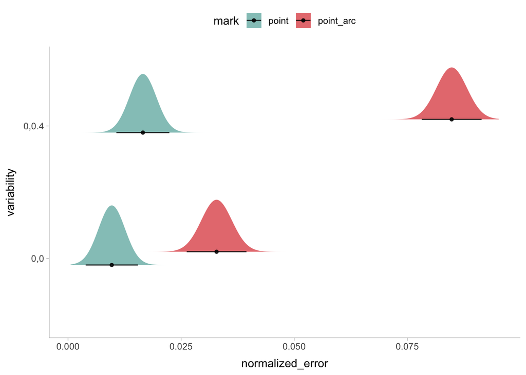

```r
p_og <- exp2 %>%
  summarySEwithin(
    data = .,
    measurevar = "normalized_error",
    withinvars = "variability",
    betweenvars = "mark",
    idvar = "assignmentid"
  ) %>%
  plot_results(., normalized_error)

p_og
```

## Adding Additional Factors to OG Graph

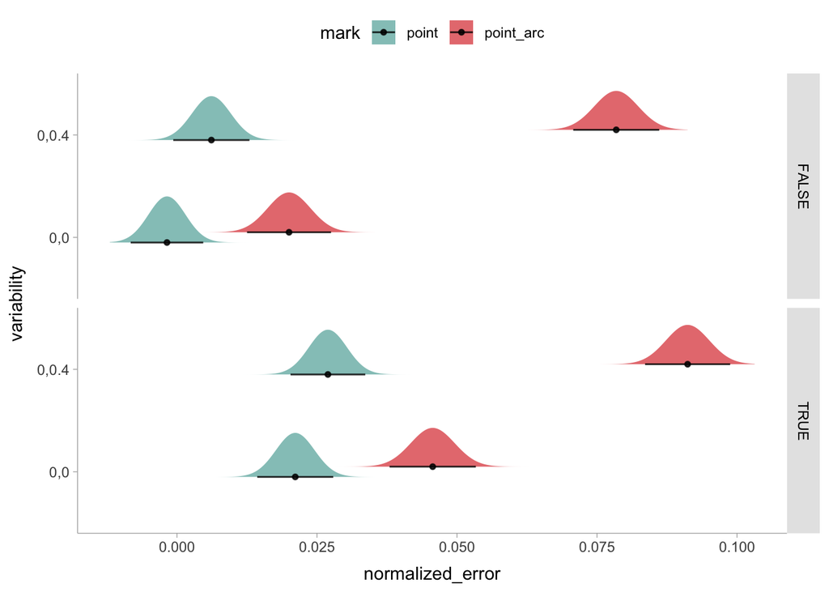

```r
exp2 %>%
  summarySEwithin(
    data = .,
    measurevar = "normalized_error",
    withinvars = c("variability", "flip"), # <- new
    betweenvars = "mark",
    idvar = "assignmentid"
  ) %>%
  plot_results(., normalized_error) +
  facet_grid(flip ~ .)
```

## Recalculate error

First, let’s see what’s the difference between the average data average and the average that Moritz et al. used for their error analysis. Let’s first look at how Moritz et al is reporting things in their dataset:

```r
raw_exp2 %>%
  select(stimuliindex, seed, mark, flip, variability, average, data_average) %>%
  group_by(
    stimuliindex,
    seed,
    mark,
    flip,
    variability,
    average,
    data_average
  ) %>%
  summarise(.) %>%
  print(n = 8)
```

```
# A tibble: 96 × 7
# Groups:   stimuliindex, seed, mark, flip, variability, average [96]
  stimuliindex  seed mark      flip  variability average data_average
         <int> <int> <chr>     <lgl> <chr>         <dbl>        <dbl>
1            4     1 point     FALSE 0,0           0.513        0.513
2            5     1 point     TRUE  0,0           0.487        0.487
3            6     1 point     FALSE 0,0.4         0.513        0.513
4            7     1 point     TRUE  0,0.4         0.487        0.487
5            8     1 point_arc FALSE 0,0           0.513        0.495
6            9     1 point_arc TRUE  0,0           0.487        0.505
7           10     1 point_arc FALSE 0,0.4         0.513        0.583
8           11     1 point_arc TRUE  0,0.4         0.487        0.417
# ℹ 88 more rows
```

Observe that for stimuli that share the same `seed`, the `data_average` is the actual average of the dataset, while the `average` is the same for stimuli index that share the same `seed`, `flip`, and `variability`[^2].

<sup>2</sup> for example examine `stimuliindex == 4` and `stimuliindex == 8`

**NoteVerify that `data_average` is true average**

To verify that it is indeed the case the `data_average` is true average, we can look at the actual stimuli that Moritz et al. provided:

```r
ans_df <- stimuli_df %>%
  rename(stimuliindex = index) %>%
  unnest(data) %>%
  group_by(stimuliindex, seed, noise, flip, type) %>%
  rename(mark = type, variability = noise) %>%
  mutate(variability = ifelse(variability == "c(0, 0)", "0,0", "0,0.4")) %>%
  summarise(mean.y = mean(y))

ans_df
```

| stimuliindex | seed | variability | flip | mark | mean.y |
| --- | --- | --- | --- | --- | --- |
| 4 | 1 | 0,0 | FALSE | point | 0.5127005 |
| 5 | 1 | 0,0 | TRUE | point | 0.4872995 |
| 6 | 1 | 0,0.4 | FALSE | point | 0.5127005 |
| 7 | 1 | 0,0.4 | TRUE | point | 0.4872995 |
| 8 | 1 | 0,0 | FALSE | point_arc | 0.4947709 |
| 9 | 1 | 0,0 | TRUE | point_arc | 0.5052291 |
| 10 | 1 | 0,0.4 | FALSE | point_arc | 0.5831573 |
| 11 | 1 | 0,0.4 | TRUE | point_arc | 0.4168427 |
| 16 | 2 | 0,0 | FALSE | point | 0.4287062 |
| 17 | 2 | 0,0 | TRUE | point | 0.5712938 |

[output cut: 86 more lines]

Join and check:

```r
ans_df %>%
  left_join(
    raw_exp2 %>%
      select(
        stimuliindex,
        seed,
        mark,
        flip,
        variability,
        average,
        data_average
      ) %>%
      group_by(
        stimuliindex,
        seed,
        mark,
        flip,
        variability,
        average,
        data_average
      ) %>%
      summarise(.)
  ) %>%
  ungroup(.) %>%
  count(near(mean.y, data_average))
```

| near(mean.y, data_average) | n |
| --- | --- |
| TRUE | 96 |

Thus this completes the verification. Indeed `data_average` corresponds to the actual average.

This allows us to calculate two kinds of error: (1) reference error, i.e., error that uses the reference average, and (2) actual error, i.e., error that uses the true underyling dataset.

```r
exp2 <- raw_exp2 %>%
  select(
    assignmentid,
    mark,
    flip,
    variability,
    reportedaverage,
    average,
    data_average,
    error
  )

exp2 %>% head(5)
```

| assignmentid | mark | flip | variability | reportedaverage | average | data_average | error |
| --- | --- | --- | --- | --- | --- | --- | --- |
| 3C44YUNSI2PS5YV5YCV0B058A80PDO | point_arc | FALSE | 0,0 | 0.5840625 | 0.4001189 | 0.4390840 | 0.18394364 |
| 3X66WABAJXIOAT0924Z14I54I4OG3D | point_arc | FALSE | 0,0.4 | 0.4940625 | 0.4015207 | 0.4832300 | 0.09254181 |
| 3LJ7UR74RIDF2H0ZPMHF4767XG6N4D | point_arc | TRUE | 0,0 | 0.4381250 | 0.5053195 | 0.5176108 | -0.06719452 |
| 358UUM7WR03X02AAKRW3G3VRPFL7R5 | point_arc | FALSE | 0,0 | 0.0990625 | 0.4015207 | 0.4235269 | -0.30245819 |
| 3WQ3B2KGE9GW99EJZET4FEZA47IB1Z | point_arc | TRUE | 0,0 | 0.7090625 | 0.5660731 | 0.5525202 | 0.14298943 |

Check to see that the original reported `error` is obtained via difference between `reportedaverage` and `average`:

```r
exp2 %>% count(near(reportedaverage - average, error))
```

| near(reportedaverage - average, error) | n |
| --- | --- |
| FALSE | 2 |
| TRUE | 13438 |

Apparently there are two rows where it’s not near …? Let’s check:

```r
exp2 %>%
  filter(!near(reportedaverage - average, error)) %>%
  mutate(calc_error = reportedaverage - average)
```

| assignmentid | mark | flip | variability | reportedaverage | average | data_average | error | calc_error |
| --- | --- | --- | --- | --- | --- | --- | --- | --- |
| 34QN5IT0T0RD0MVU0J5UA7QZRUY08Z | point | FALSE | 0,0 | 0.2566666 | 0.2566047 | 0.2566047 | 6.19e-05 | 6.1923e-05 |
| 3GD6L00D3TXSS0IGQ3JDTUA4GZ3M12 | point | TRUE | 0,0.4 | 0.5661250 | 0.5660731 | 0.5660731 | 5.20e-05 | 5.1958e-05 |

This appears to just be due to rounding error. So this confirms that indeed `error = reportedaverage - average`.

## Reanalyze with different error definition

Using the exact same calculations, we obtain the following:

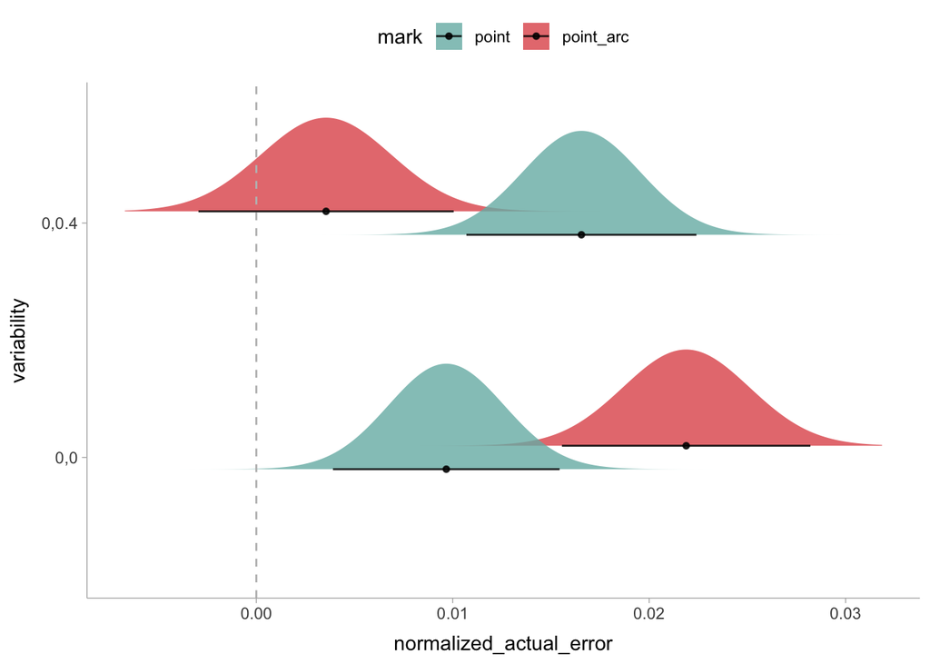

```r
exp2 %>%
  rename(ref_error = error) %>%
  mutate(
    actual_error = reportedaverage - data_average,
    normalized_actual_error = ifelse(flip == TRUE, -actual_error, actual_error)
  ) %>%
  summarySEwithin(
    data = .,
    measurevar = "normalized_actual_error",
    withinvars = "variability",
    betweenvars = "mark",
    idvar = "assignmentid"
  ) %>%
  plot_results(., normalized_actual_error) +
  geom_vline(xintercept = 0, linetype = "dashed", color = "gray")
```

If we don’t use the “normalization”, and facet by the factor of `flip`, then we get this:

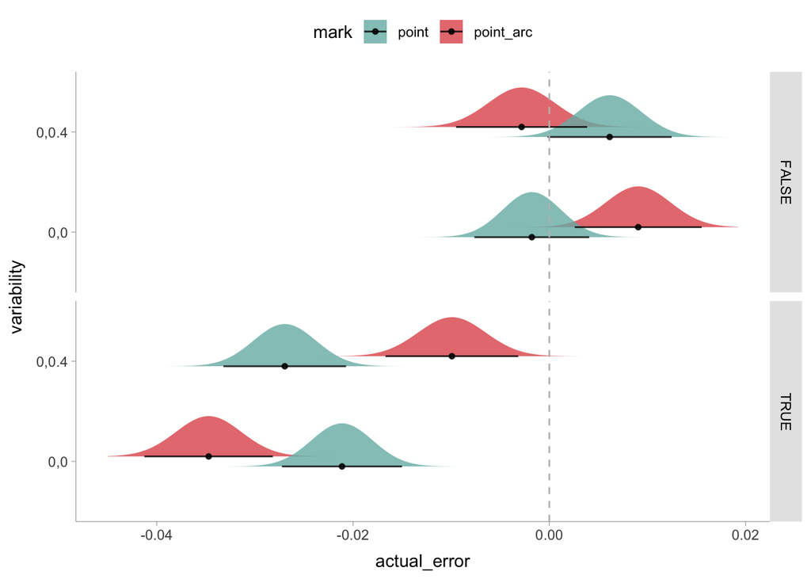

```r
exp2 %>%
  rename(ref_error = error) %>%
  mutate(
    actual_error = reportedaverage - data_average,
    normalized_actual_error = ifelse(flip == TRUE, -actual_error, actual_error)
  ) %>%
  summarySEwithin(
    data = .,
    measurevar = "actual_error",
    withinvars = c("variability", "flip"),
    betweenvars = "mark",
    idvar = "assignmentid"
  ) %>%
  plot_results(., actual_error) +
  geom_vline(xintercept = 0, linetype = "dashed", color = "gray") +
  facet_grid(flip ~ .)
```

We can also make the direction look nicer and easier to read:

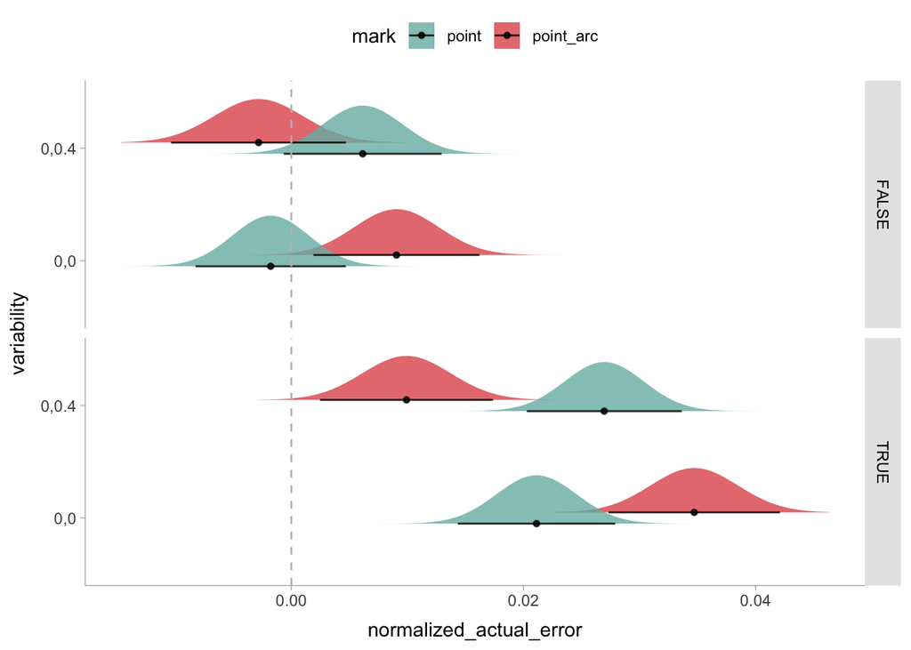

```r
exp2 %>%
  rename(ref_error = error) %>%
  mutate(
    actual_error = reportedaverage - data_average,
    normalized_actual_error = ifelse(flip == TRUE, -actual_error, actual_error)
  ) %>%
  summarySEwithin(
    data = .,
    measurevar = "normalized_actual_error",
    withinvars = c("variability", "flip"),
    betweenvars = "mark",
    idvar = "assignmentid"
  ) %>%
  plot_results(., normalized_actual_error) +
  geom_vline(xintercept = 0, linetype = "dashed", color = "gray") +
  facet_grid(flip ~ .)
```

It seems to me that there are several things that are unexplained in the original analysis:

- When the original plot is flipped (when `flip == TRUE`), there seems to be a bigger bias compared to the case when it’s not flipped.
- When calculating error using the true mean, instead of the mean for the plot with the same seed, we don’t see the same trend that more variability implies bigger error.

## What is the relationship between actual mean and reference mean, vs the plot type?

As the title states, for the plots that share the same reference line, does being `pointArc` imply more variability?

```r
s_df <- raw_exp2 %>%
  select(
    stimuliindex,
    seed,
    mark,
    flip,
    variability,
    average,
    data_average
  ) %>%
  group_by(
    stimuliindex,
    seed,
    mark,
    flip,
    variability,
    average,
    data_average
  ) %>%
  summarise(.)

s_df %>% head(5)
```

| stimuliindex | seed | mark | flip | variability | average | data_average |
| --- | --- | --- | --- | --- | --- | --- |
| 4 | 1 | point | FALSE | 0,0 | 0.5127005 | 0.5127005 |
| 5 | 1 | point | TRUE | 0,0 | 0.4872995 | 0.4872995 |
| 6 | 1 | point | FALSE | 0,0.4 | 0.5127005 | 0.5127005 |
| 7 | 1 | point | TRUE | 0,0.4 | 0.4872995 | 0.4872995 |
| 8 | 1 | point_arc | FALSE | 0,0 | 0.5127005 | 0.4947709 |

Now let’s plot the density and mean:

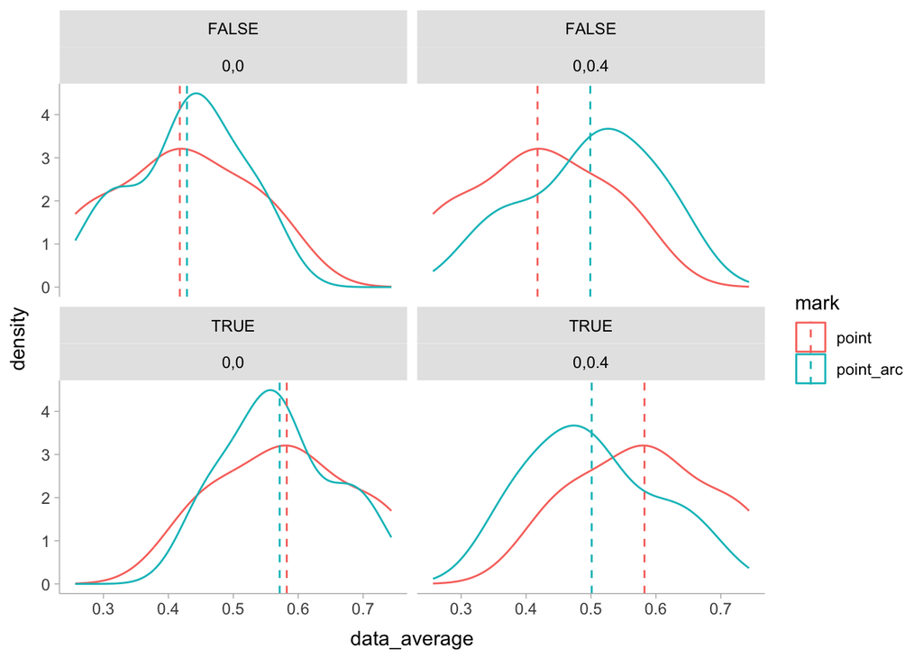

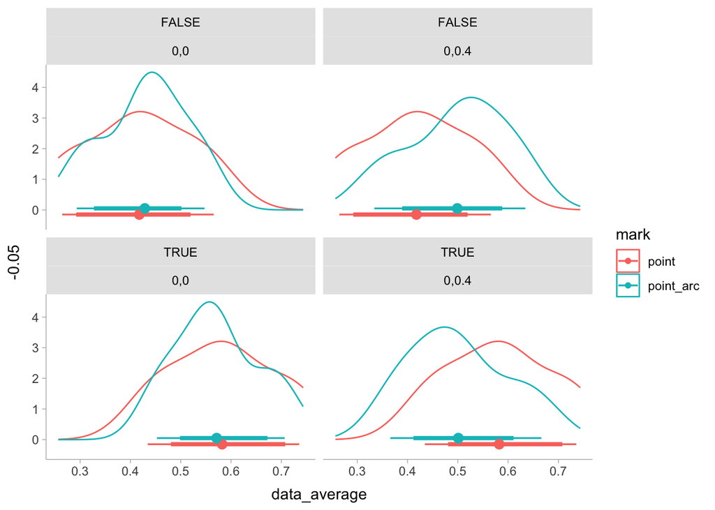

```r
means_df <- s_df %>%
  group_by(flip, variability, mark) %>%
  summarize(mean_val = mean(data_average), .groups = "drop")

s_df %>%
  ggplot(aes(x = data_average, color = mark)) +
  geom_density() +
  geom_vline(
    data = means_df,
    aes(xintercept = mean_val, color = mark),
    linetype = "dashed"
  ) +
  facet_wrap(flip + variability ~ .)
s_df %>%
  ggplot(aes(x = data_average, color = mark)) +
  geom_density() +
  stat_pointinterval(
    aes(y = -0.05),
    point_interval = mean_qi,
    position = position_dodge(width = 0.4)
  ) +
  facet_wrap(flip + variability ~ .)
```